# Case Study 1

Laura Jarzombek

October 29, 2016

# Case Study 1 - RMARKDOWN Document

## Introduction:

### For my project, I will analyze several datasets and will use information gathered from those datasets to provide insight into gross domestic product (GDP) levels and related income levels of different countries. The original data sources can be found at the World Bank website. The World Bank is an international financial institution that provides loans to developing countries for capital programs. The World Bank also provides free and open access to global development data that it collects at its website at data.worldbank.org. The two datasets that I chose to use for this project contained both GDP data as well as educational data for various countries. After tidying the two separate datasets, I merged the datasets and performed analysis using five different scenarios. Further information, analysis, and a conclusion can be found below.

## Instruction for Case Study:

### Load the Gross Domestic Product data for the 190 ranked countries in this data set:

### https://d396qusza40orc.cloudfront.net/getdata%2Fdata%2FGDP.csv

### Load the educational data from this data set:

### https://d396qusza40orc.cloudfront.net/getdata%2Fdata%2FEDSTATS_Country.csv

### Original data sources (if the links above don’t work):

### http://data.worldbank.org/data-catalog/GDP-ranking-table

### http://data.worldbank.org/data-catalog/ed-stats =

## Downloading the Files.

### Libraries needed to clean and analyze data:

```r
library(repmis)
library(RCurl)
library(tidyr)
library(dplyr)
```

```r
library(ggplot2)
#I loaded the above files so that my code used during the analysis portion will run correctly. Other libraries could be used to complete this Case Study. The selection will vary with code used.
```

## Loaded both datasets in the instructions above.

### First dataset loaded: I loaded the GDP for 190 ranked countries dataset:

```r
site="https://d396qusza40orc.cloudfront.net/getdata%2Fdata%2FGDP.csv"    #Load file from website.
getwd() #Set Working Directory.
```

```
## [1] "C:/Users/Laura/Documents/Case-Study-1"
```

```r
download.file(site, destfile = "./FGDP.csv")  #Download file and name to local drive.
list.files()  #List all files in my current directory.
```

```
## [1] "Case-Study-1.Rproj"            "Case Study 1.R"
## [3] "CaseStudyDocument.html"        "CaseStudyDocument.Rmd"
## [5] "FEDSTATS_Country.csv"          "FGDP.csv"
## [7] "LJarzombekCaseStudy1.RMD.html" "New Text Document.txt"
## [9] "README.md"
```

```r
GDP<-read.csv("FGDP.csv", header=F, skip=5,nrows = 190)  #Read file.
GDP # Run the Dataset.
```

```
##      V1  V2 V3                             V4           V5 V6 V7 V8 V9 V10
## 1   USA   1 NA                  United States  16,244,600     NA NA NA  NA
## 2   CHN   2 NA                          China   8,227,103     NA NA NA  NA
## 3   JPN   3 NA                          Japan   5,959,718     NA NA NA  NA
## 4   DEU   4 NA                        Germany   3,428,131     NA NA NA  NA
## 5   FRA   5 NA                         France   2,612,878     NA NA NA  NA
## 6   GBR   6 NA                 United Kingdom   2,471,784     NA NA NA  NA
## 7   BRA   7 NA                         Brazil   2,252,664     NA NA NA  NA
## 8   RUS   8 NA             Russian Federation   2,014,775     NA NA NA  NA
## 9   ITA   9 NA                          Italy   2,014,670     NA NA NA  NA
## 10  IND  10 NA                          India   1,841,710     NA NA NA  NA
## 11  CAN  11 NA                         Canada   1,821,424     NA NA NA  NA
## 12  AUS  12 NA                      Australia   1,532,408     NA NA NA  NA
## 13  ESP  13 NA                          Spain   1,322,965     NA NA NA  NA
## 14  MEX  14 NA                         Mexico   1,178,126     NA NA NA  NA
```

[output cut: 176 more lines]

```r
dim(GDP)  #Look at the dimensions of the dataset.
```

```
## [1] 190  10
```

### Second dataset loaded: I loaded educational data from the following dataset:

```r
site="https://d396qusza40orc.cloudfront.net/getdata%2Fdata%2FEDSTATS_Country.csv"  #Load file from website.
getwd() #Set Working Directory.
```

```
## [1] "C:/Users/Laura/Documents/Case-Study-1"
```

```r
download.file(site, destfile = "./FEDSTATS_Country.csv") #Download file and name to local drive.
list.files() #List all files in my current directory.
```

```
## [1] "Case-Study-1.Rproj"            "Case Study 1.R"
## [3] "CaseStudyDocument.html"        "CaseStudyDocument.Rmd"
## [5] "FEDSTATS_Country.csv"          "FGDP.csv"
## [7] "LJarzombekCaseStudy1.RMD.html" "New Text Document.txt"
## [9] "README.md"
```

```r
FEDSTATS<-read.csv("FEDSTATS_Country.csv", header=TRUE)  #Read file.
FEDSTATS # Run the Dataset.
```

```
##     CountryCode
## 1           ABW
## 2           ADO
## 3           AFG
## 4           AGO
## 5           ALB
## 6           ARE
## 7           ARG
## 8           ARM
## 9           ASM
## 10          ATG
## 11          AUS
## 12          AUT
## 13          AZE
## 14          BDI
```

[output cut: 3980 more lines]

```r
dim(FEDSTATS)  #Look at the dimensions of the dataset.
```

```
## [1] 234  31
```

### What do these datasets look like?

```r
str(FEDSTATS)  # Get an idea of what the columns, rows, and data files look like. It will also tell you if values are factors or intergers.
```

```
## 'data.frame':    234 obs. of  31 variables:
##  $ CountryCode                                      : Factor w/ 234 levels "ABW","ADO","AFG",..: 1 2 3 4 5 6 7 8 9 10 ...
##  $ Long.Name                                        : Factor w/ 234 levels "American Samoa",..: 5 104 57 99 108 226 4 109 1 2 ...
##  $ Income.Group                                     : Factor w/ 6 levels "","High income: nonOECD",..: 2 2 4 5 6 2 6 5 6 6 ...
##  $ Region                                           : Factor w/ 8 levels "","East Asia & Pacific",..: 4 3 7 8 3 5 4 3 2 4 ...
##  $ Lending.category                                 : Factor w/ 4 levels "","Blend","IBRD",..: 1 1 4 4 3 1 3 2 1 3 ...
##  $ Other.groups                                     : Factor w/ 3 levels "","Euro area",..: 1 1 3 1 1 1 1 1 1 1 ...
##  $ Currency.Unit                                    : Factor w/ 155 levels "","Afghan afghani",..: 8 49 2 5 3 144 6 7 145 44 ...
##  $ Latest.population.census                         : Factor w/ 28 levels "","1970","1979",..: 17 28 3 2 18 22 18 18 17 18 ...
##  $ Latest.household.survey                          : Factor w/ 56 levels "","CPS (monthly)",..: 1 1 39 38 40 1 1 16 1 1 ...
##  $ Special.Notes                                    : Factor w/ 70 levels "","A simple multiplier is used to convert the national currencies of EMU members to euros. The following irrevocable euro conversi"| __truncated__,..: 1 1 27 1 1 1 1 1 1 63 ...
##  $ National.accounts.base.year                      : Factor w/ 44 levels "","1954","1973",..: 25 1 38 28 1 25 22 1 1 18 ...
##  $ National.accounts.reference.year                 : int  NA NA NA NA 1996 NA NA 1996 NA NA ...
##  $ System.of.National.Accounts                      : int  NA NA NA NA 1993 NA 1993 1993 NA NA ...
##  $ SNA.price.valuation                              : Factor w/ 3 levels "","VAB","VAP": 1 1 2 3 2 2 2 2 1 2 ...
```

[output cut: 17 more lines]

```r
str(GDP)      # Get an idea of what the columns, rows, and data files look like.  It will also tell you if values are factors or intergers.
```

```
## 'data.frame':    190 obs. of  10 variables:
##  $ V1 : Factor w/ 190 levels "ABW","AFG","AGO",..: 179 34 87 45 58 61 25 145 84 78 ...
##  $ V2 : int  1 2 3 4 5 6 7 8 9 10 ...
##  $ V3 : logi  NA NA NA NA NA NA ...
##  $ V4 : Factor w/ 190 levels "Afghanistan",..: 182 37 85 64 60 181 25 141 83 77 ...
##  $ V5 : Factor w/ 189 levels " 1,008 "," 1,129 ",..: 39 177 142 99 65 62 60 57 56 15 ...
##  $ V6 : Factor w/ 7 levels "","a","b","c",..: 1 1 1 1 1 1 1 1 1 1 ...
##  $ V7 : logi  NA NA NA NA NA NA ...
##  $ V8 : logi  NA NA NA NA NA NA ...
##  $ V9 : logi  NA NA NA NA NA NA ...
##  $ V10: logi  NA NA NA NA NA NA ...
```

## Before I merged the data, I decided to tidy the datasets.

### First, I looked at the raw data files. They were both in .csv (or Excel) files. I figured out which rows and columns to delete.It’s important to think ahead to decide what analysis you want to perform when you are tidying up your dataset.

### Tidying the Data. I noticed that there’s one large dataset (FEDSTATS) and a smaller dataset (GDP).

### Starting with the smaller dataset (GDP), I performed the following:

### Within the GDP dataset, I subsetted the data by Country Code (“CountryCode”) and Rank (“Rank”). I already skipped the first 5 empty rows and only included 190 countries when I brought in the .csv file.

## Cleaning the GDP Dataset.

```r
GDP1<-GDP[,c(1,2,4,5)]    #Subset data and only keep certain columns.
names(GDP1)<-c("CountryCode", "Rank","LongName","gdp")  #Rename columns of subset data.
GDP1   #Cleaned GDP subsetted Dataset.
```

```
##     CountryCode Rank                       LongName          gdp
## 1           USA    1                  United States  16,244,600
## 2           CHN    2                          China   8,227,103
## 3           JPN    3                          Japan   5,959,718
## 4           DEU    4                        Germany   3,428,131
## 5           FRA    5                         France   2,612,878
## 6           GBR    6                 United Kingdom   2,471,784
## 7           BRA    7                         Brazil   2,252,664
## 8           RUS    8             Russian Federation   2,014,775
## 9           ITA    9                          Italy   2,014,670
## 10          IND   10                          India   1,841,710
## 11          CAN   11                         Canada   1,821,424
## 12          AUS   12                      Australia   1,532,408
## 13          ESP   13                          Spain   1,322,965
## 14          MEX   14                         Mexico   1,178,126
```

[output cut: 176 more lines]

### Did not clean up dataset FEDSTATS dataset because I noticed that it’s relatively clean and I can call data and merge the data into the other dataset (GDP1).

# Analysis Portion

## Analysis 1: Merge the data based on the country shortcode. How many of the IDs match?

```r
data1<-merge(GDP1,FEDSTATS,by='CountryCode')   #Merge both datasets by CountryCode.
nrow(data1)                                   #Run the command code.
```

```
## [1] 189
```

### Answer: A merge of the data based on the country shortcode was performed for this analysis. Based on the merge of the Country Education Data and the GDP Ranking, there were 189 IDs that match.

## Analysis 2: Sort the data frame in ascending order by GDP (so United States is last). What is the 13th country in the resulting data frame?

```r
library(dplyr)  #This library is important here.
data2<-arrange(data1,desc(Rank)) [13,3]   #Ascending order and 13th country in third row indicated.
data2  #Ran data.
```

```
## [1] St. Kitts and Nevis
## 190 Levels: Afghanistan Albania Algeria Angola ... Zimbabwe
```

### Answer: A sort of the data frame was done in ascending order by GDP (so United States is last). Saint Kitts and Nevis is the 13th country on the list.

## Analysis 3: What are the average GDP rankings for the “High income: OECD” and “High income: nonOECD” groups?

### I merged both datasets.

```r
both<-merge(GDP1,FEDSTATS, by.x = "CountryCode", by.y = "CountryCode")  #Merge datasets by Country Code.
both<-both[,c("CountryCode","Rank", "Long.Name", "Income.Group")]      #Name the columns.
both<-both[order(both$Rank),]                                          #Sort by a factor.
mean(both[which(both$Income.Group == "High income: OECD"), ]$Rank)     #Found mean of high income:OECD group.
```

```
## [1] 32.96667
```

```r
mean(both[which(both$Income.Group == "High income: nonOECD"), ]$Rank)   #Found mean of high income:nonOECD group.
```

```
## [1] 91.91304
```

## Analysis 4: Plot the GDP for all of the countries. Use ggplot2 to color your plot by Income Group.

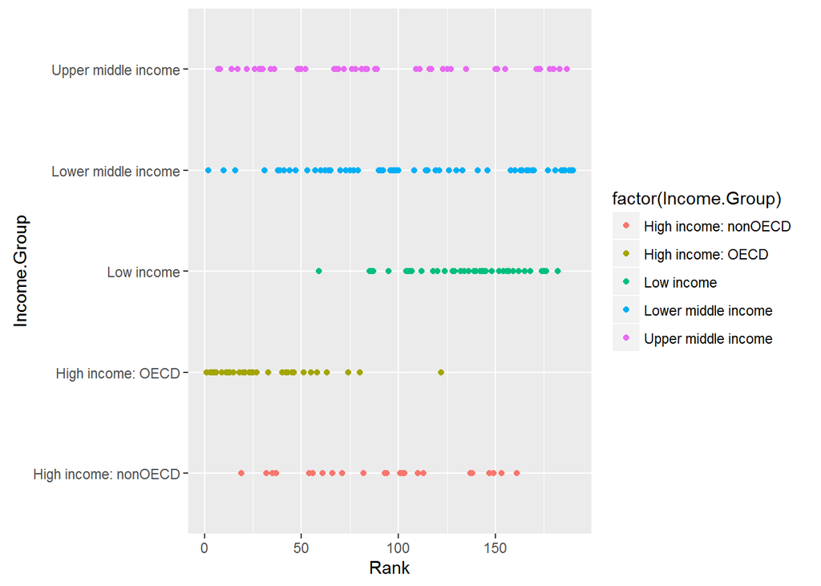

```r
library(ggplot2)  #This library is important here.
Graph<-ggplot(both, aes(Rank, Income.Group, color=factor(`Income.Group`)))+geom_point()  #Plot Income.Group against country rankings.
Graph   #Run the Code.
```

### Answer: The resulting graph shows that ranks vary among income groups for the countries. Country income and country rank does not appear to be directly coorelated in all instances.

## Analysis 5: Cut the GDP ranking into 5 separate quantile groups. Make a table versus Income.Group. How many countries are Lower middle income but among the 38 nations with highest GDP?

```r
BREAK <- with(both, quantile(Rank, probs = c(0, 0.20, 0.40, 0.60, 0.8, 1)))  # Five seperate quantile groups.
BREAK2<- within(both, quantile <- cut(Rank, breaks = BREAK, labels = 1:5, include.lowest = TRUE))  #Additional code to seperate into quantile groups.

Table1<-table(BREAK2$quantile, both$"Income.Group")

#Made a table versus Income.Group.#How many countries are Lower middle income but among the 38 nations with highest GDP.

LowerMiddleIncome <- subset(BREAK2, `Income.Group` == "Lower middle income")

#Creates subset for Lower Middle Income.
LowerMiddleIncomeTop38GDP <- subset(LowerMiddleIncome, Rank <= 38) #Creates additional subset with top 38 GDPs.
LowerMiddleIncomeTop38GDP[c(1:2)] #Creates list of GDPs with both that are both in the lower Middle income group and in top 38 GDPs.
```

```
##     CountryCode Rank
## 34          CHN    2
## 78          IND   10
## 77          IDN   16
## 165         THA   31
## 51          EGY   38
```

### Answer: Five countries are in the lower middle income group that are in the top 38 nations with the highest GDP. The short codes for these countries are as follows: CHN (The People’s Republic of China), IND (Republic of India), IDN(Indonesia), THA(Thailand), EGY(Egypt).

## Conclusion:

### As the data and analysis suggests, a country’s GDP and the average income of the country are not necessarily directly correlated. Within these datasets, there are several countries that have higher GDPs where the country’s income level is lower (and vice versa). This is because GDP isn’t the same as average income. GDP measures economic output of a country. GDP not only measures the total income of everyone in an economy but also the total expenditure on the economy’s output of goods and services. The differences between income and GDP could exist because of a multitude of reasons, including education levels, population, government type, profit distortion by top earners, etc. The bigger the spread between income and GDP is indicative of income inequality for a country.